# Linking R and GitHub: part 2

Simon Brewer

10/16/2020

# 1 R and GitHub

We’ll now look at how to integrate GitHub with RStudio through the use of R projects. We’ll also look at the use of GitHub Pages and how to undo your changes with git. There are a couple of ways of connecting R with GitHub, but the following method is pretty reliable.

## 1.1 Make a new repository on GitHub

We covered this in the previous lab, but let’s do this again. Go to [GitHub](https://github.com), make sure you are logged in and go to [Repositories]. Click the green button to make a new repository. Call this `my-r-repo`, and add a short description (something like `testing RStudio setup`). Make sure the check-box to initialize the repository with a README is checked and click [Create repository]. Once created, click the button [Clone or download], and copy the HTTPS URL (if you click on the little clipboard icon this will get copied to your clipboard).

## 1.2 Make a new RStudio project

To connect this to RStudio, we need to make an RStudio project. This is a little different from the regular R scripts, and acts like a git repository to store a set of files in a common setting. Open RStudio, and make a new project from [File] > [New Project]. Click on [Version Control], then [Git] (Clone a project from a Git repository).

On the next screen, add the URL you copied from GitHub to the box labeled [Repository URL]. For the next box, accept the given project directory name (this should be the same as the GitHub repository). The final box gives the directory where the repository will be cloned to on your computer. Make sure this is ok, and that the check-box [Start in new session] is checked. Now click [Create project].

RStudio will restart, launching a new local RStudio Project that connects to the repository on GitHub. It will download the README file, and this should appear in the file browser panel.

If all this has worked, congratulations - you have successfully linked RStudio to your GitHub account, and can now make changes and push these to GitHub. Note that nearly all these instructions only need to be carried out once. The only part of this you will do routinely is the last part: creating new projects for different bits of work you are carrying out.

## 1.3 Start making changes to your project

Let’s try and make some changes. First, make sure the README.md file is open in the files panel. If not, click on the file browser, which will show you the contents of the project directory, and double click the `README.md` file. Add a small amount of text to this (I’ll leave this up to you).

If you now look at the RStudio panel with the [Environment], [History] and [Connections] tabs, you should see a new one labeled [Git]. Click on this and you should see your READ.md file with a small blue ‘M’ next to it. This indicates that this file has been modified and is different from the version downloaded from GitHub. If you’re happy with the changes you made, click on the check-box next to the ‘M’ (under the heading ‘Staged’) to stage these changes for uploading.

Now click the [Commit] button. A new window will open showing a) all the files; b) the staged files with a check mark; c) a blank panel to add a commit message; d) a display of which lines have been changed in the currently highlit file (green for additions, red for deletions). Check that your file is still listed as ‘Staged’ and add a commit message; a short description of the changes. Once this is done, click [Commit] to commit your changes. This effectively creates an updated local version of the repository, including the staged changes. However, if you check your GitHub repository, and look at the README file there, you will see that the changes have not yet been uploaded. To do this, we need to push the changes. Click the [Push] button (either in the Git panel or in the Review changes windowand you should see a short message detailing the upload. Go back to your browser and recheck the README file and you should see your changes appear (refresh the browser page if they are not there).

Now let’s add an R script. In RStudio, click [File] > [New File] > [R Script] to open a blank R script. Add the following R code to this script:

```r
## OLS example
x = rnorm(100, mean = 20, sd = 5)
y = x + rnorm(100, mean = 0, sd = 2)

fit = lm(y ~ x)

summary(fit)
```

This simply generates some correlated random numbers and builds a linear model between them, and prints out the results of that model. Save the script file as ‘lmExample.R’ and then click ‘Run’ from the scripting window. This will run all the code and allow you to check for mistakes. If all is ok, go through the same steps to commit the changes:

- Click on [Commit] from the ‘Git’ tab
- Stage the files you want to push (note that any new file will be staged with a green ‘A’ next to it, indicating that it is going to be added)
- Add a commit message
- Push to GitHub
- Check that your changes are on your GitHub site

Let’s add a couple more changes. First, we’ll add code to plot the data, and the model fit to the end of the file:

```r
plot(x,y)
abline(fit, col=2)
```

Run to check your code (and the beautiful plot you get), and then stage, commit and push your changes. Make any other changes that you would like to, and when you are done, commit/push these and then close RStudio.

# 2 Using branches in RStudio

We covered the use of branches in the previous lab as a way of allowing development of code in parallel to an established `main` branch. RStudio has added support for the use of branches fairly recently, and we’ll go through the steps of setting up a branch, developing with it, and finally merging it back to the `main` repository.

We’ll continue using the `my-r-repo` repository that you just created. If it is not currently open in RStudio, find the R project file (*my-r-repo.Rproj*) and double click it to open it. Next click the [Pull] button in the Git tab to make sure your local copy is up-to-date. This might seem unnecessary, but it is a good practice to always click and check for updates before changing anything.

Now we’ll create a new branch. In the Git panel in RStudio, find the New Branch button. This has two connected purple rectangles and looks like this:

[figure not shown]

Clicking this will open a small window, where you can enter the name of a new branch. Add a name and click [Create]. This will now create a new branch, push it to your GitHub repository and set RStudio to work in the new repository. If you want to checkout a different branch (e.g. you want to switch back to the `main` branch), click on the drop down menu next to the New Branch button.

Now let’s add some code. The following is just some simple code to make a plot from a file, feel free to replace this with your own code if you’d prefer. Rather than a simple script, we’ll make a function to make the plots. Open a new R script and enter the following code:

```r
plot_ts <- function(x, y, ...) {
  fit <- mgcv::gam(y ~ s(x))
  plot(x, y, type = 'l', ...)
  lines(x, fitted(fit), col = 2, lwd = 2)
}
```

This function will plot some time series data and add a smoothing line based on a GAM fit. Save the script as *plot_ts.R* and push it to GitHub with a suitable commit message.

Next, we’re going to add a data file to the repository for plotting. Get the Mauna Loa CO$_2$ file (*co2_mm_mlo.csv*) from the slack channel/email chain and add it to the project directory on your computer. If you’ve forgotten where this is, typing the following command will print R’s current directory

```r
getwd()
```

Note that you can make several local commits in this way, and then push them all to GitHub on one go. This can be useful if your connection is limited in any way. We’ll add a simple R script that reads the Mauna Loa CO$_2$ file and plots it using this function. Open a new script and add the following code (note we need to load both the data and the file containing the plot function.

```r
# Load function
source("plot_ts.R")
# Load file
co2 <- read.csv("co2_mm_mlo.csv")
# Make plot
plot_ts(co2$decdate, co2$interpolated, main = "Mauna Loa CO2 record")
```

Save and run your script, and if it all works you should see the following, exciting plot.

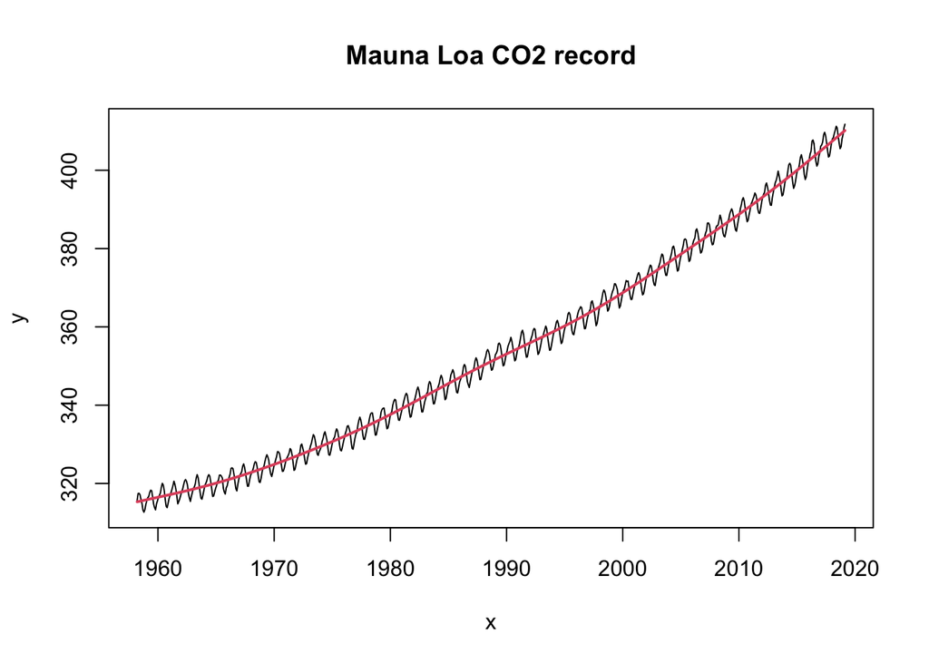

Now commit and push this to GitHub (note that this will push the previous commit as well). Finally, go back to your browser and check that everything has uploaded correctly.

If you want to see a list of the changes that you have made (i.e. the equivalent to `git log`), simply click the [History] button in the Git tab in RStudio to show a window with the individual commits (top panel) and the diffs (changes; bottom panel):

[figure not shown]

Next, we’ll merge these changes back into the `main` branch. Feel free to make other changes before this, just remember to commit and push them to GitHub. Go to your GitHub repository page now, and you should see a highlit box at the top of the page telling you that the new branch had a recent push. Click on the green button [Compare and pull request] to open a pull request. git will run a check for conflicts, and if none are found you should see this banner:

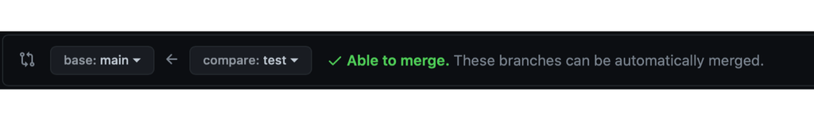

If no problems have been found, fill out the pull request (title and explanatory text), and click [Create pull request]. The next page lists the details of the proposed merge as well as a section for comments (this will make more sense when we look at collaborative work). Click [Merge pull request] and [Confirm request]. Once the branches are merged, GitHub will give you the option to delete the new branch, and you should do so. It is generally cleaner to make a new branch for the next development step than to re-use an existing branch once you are finished with it. Go back to the main repository page and you should see that your changes have been integrated.

Now let’s update your local `main` repository. Go back to RStudio, choose `main` from the drop-down branch menu (top right). This will probably delete some files, but don’t panic (!), you will get them back from GitHub in a moment. Click [Pull] and git will download the new files, bringing your local `main` into line with the remote copy.

When all this is done, we can clean up the local repositories. Go to the terminal in RStudio and type

```
git branch
```

To see the list of branches. This should look something like

```
* main
  test
```

If the `*` is not next to `main`, type `git checkout main` to move to that branch. We can now delete the `test` branch:

```
git branch -d test
```

And finally run this command to clean up any missing links:

```
git fetch --prune
```

# 3 GitHub pages

If you click on the name of any of the files in your repository, GitHub will show you the contents as long as they are text files. If you add an HTML document to your repo, GitHub will not try to render it, but simply show you the underlying code. If you want to show the rendered HTML, you need to use GitHub pages instead. This requires a little more set up, but is worth knowing as you can generate HTML pages using R Markdown, then push these and make them publicly visible (like this document).

You can do these steps in one of your existing repositories or create a new one. Either way, make sure that you have an R project that is linked to a GitHub repository. First, in the folder containing your local repository make a new sub folder called `docs`. Next, open an R Markdown file in RStudio, selecting HTML output. Add the following code to the header, just underneath the `title`:

```
knit: (function(input_file, encoding) {
  out_dir <- 'docs';
  rmarkdown::render(input_file,
 encoding=encoding,
 output_file=file.path(dirname(input_file), out_dir, 'index.html'))})
```

Then modify this file to run some R code and show the results. Save this file and then click the [Knit] button to make sure the HTML compiles. Now stage/commit your changes, *making sure that this includes the `docs` folder*. Now push these changes to GitHub.

Go back now to your GitHub repository and click [Settings] from the top menu. Scroll down to the section labelled `GitHub Pages`. Under ‘Source’, set ‘Branch’ to `main` and the folder to `docs/` (if you don’t see this folder, it was not uploaded in the commit).

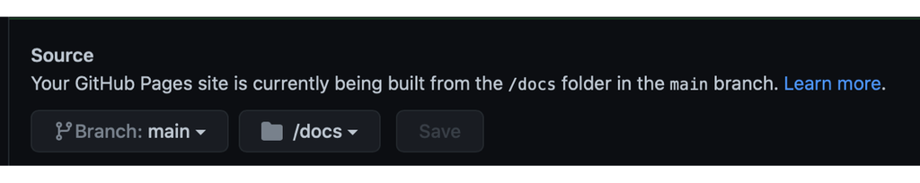

Feel free to choose a theme for your web page under ‘Theme chooser’. GitHub will now set up your webpage, and the URL will appear at the top of this section (you might need to refresh the Settings page to see this). Click on this now to open the web page.

Now if you want to make changes to the webpage, simply update the markdown in your local repository, knit it to HTML and stage/commit/push it to GitHub. Note that if you updated the theme, you will need to pull the changes back to your local repository first.

# 4 Undoing changes

By far the safest way to ‘undo’ a change in your git repository is by correcting the problem and committing this with a suitable message. However, sometimes you may need to roll back your changes to a previous commit. git has a couple of methods for doing this: `reset` and `revert`. These are command line tools, so if you want to test them, you will need to open a terminal and change directory (`cd`) to your local repository.

## 4.1 `reset`

If you have made local commits but not yet pushed these to GitHub (or any other location), then the `reset` function is fairly straightforward. Each commit that you made is accompanied by a short hexadecimal hash string called SHA1. This can be used directly with the `reset` command to move back to ab earlier version of your code. To see the SHA1 numbers, together with the accompanying commit message, simply type:

```
git log --oneline
```

The output will look something like this, with the SHA1 number in the first column, followed by the message:

```
b764644 Third commit
7c709f0 Second commit
9ef9173 First commit
```

Now to revert to the second commit, we use the corresponding number (`7c709f0`) with the reset function as follows. Note that your numbers will be different, and you should probably not run this unless you are happy to rollback.

```
git reset 7c709f0
```

If you run `git log --oneline` now, the output would look like this:

```
7c709f0 Second commit
9ef9173 First commit
```

You can also use relative changes, e.g. the following will move back two places from the current commit:

```
git reset current~2
```

## 4.2 `revert`

The `reset` function acts like the undo function in most pieces of software. It effectively removes any changes that you have made. The `revert` function works in a slightly different way by creating a *new* commit that reverses the previous changes. For example, if you had added a line of code in the last commit, then the `revert` function creates a new commit in which this line is removed. To revert to the previous commit, simply type:

```
git revert
```

Note that this is also an option in RStudio’s [Git] tab under the [More] drop-down menu. Because this adds a new commit, this will prompt you to enter a message.

The main difference is that this retains the full set of previous commits *plus* the new one, allowing a more detailed trace of your changes. If you run the `revert` command on this same example, the output from the log will now look like this:

```
11b7712 Revert "Third commit"
b764644 Third commit
7c709f0 Second commit
9ef9173 First commit
```

In general, this is the preferred method for undoing changes, particularly with repositories that are shared with other people.

Note: you can make branches using the SHA1 hash numbers of previous commits. This is an excellent way to go back and check some old code prior to resetting or reverting. For example:

```
git checkout 7c709f0
```

[NOTE THAT THIS SECTION MAY NO LONGER BE NEEDED IF YOU HAVE USED GITHUB CREDENTIAL MANAGER]

To avoid having to type in your GitHub password every time you make a request (commit, clone, etc), we can set up an SSH key pair. The key pair consists of a public and private key. The public key can be given to any server you want to connect to. When this is paired with a client that has the private key (your computer), the server unlocks without need for a password.

To do this, we need to

- Generate the SSH key pair
- Add the private key to your local SSH client
- Add the public key to GitHub

There are a variety of ways of doing this, but the easiest is to rely on built-in tools in RStudio, so start this up now.

First, it’s worth checking to see if there is already an existing key pair. Go to [Tools] > [Global Options] > [Git/SVN]. If you see something like `~/.ssh/id_rsa` in the SSH RSA Key box, you have existing keys that can be used, and you can skip the next section. If you don’t see anything, but you know that there should be a key already present, you can check this by looking at the contents of the `.ssh` directory on your computer:

```
ls -al ~/.ssh/
```

If you see a different key pair present, you can use these later on.

If not, you can generate a key pair by clicking on the [Create RSA Key…] button. RStudio will prompt you for a passphrase, but it is probably easiest to skip this for now and add it later. Click [Create] and RStudio will generate an SSH key pair, stored in the files ~/.ssh/id_rsa and ~/.ssh/id_rsa.pub (and the first of these should be shown in the SSH RSA Key box.

Now let’s add the private key to the local ssh agent. You will need to do this from a terminal. Again, the easiest way is to open the terminal in RStudio (go to [Tools] > [Terminal] > [New Terminal]) to open a terminal in the console panel. Here, first type the following to check that `ssh-agent` (the local SSH client) is running:

```
eval "$(ssh-agent -s)"
```

And you should see a process ID like this:

```
# Agent pid 95727
```

Now add the key you have created using the following command:

```
ssh-add ~/.ssh/id_rsa
```

Note that if your key pair has a different name, you will need to use that here.

Finally, we need to add the public key to GitHub. Go to [Tools] > [Global Options] > [Git/SVN]. If your key pair has the usual name, id_rsa.pub and id_rsa, RStudio will see it and offer to “View public key”. Do that and accept the offer to copy to your clipboard. If your key pair is named differently, open it using a text editor and copy the contents to your clipboard.

Now open a browser, go to [GitHub](https://github.com) and sign in. Click on the profile picture in the top right hand corner and go to [Settings] > [SSH and GPG keys]. Click [New SSH key] and then paste what you just copied into this box. Give it a title (this can be anything you like) and click [Add SSH key].

And that’s it! If you’ve made it this far, everything should be in place for you to connect to GitHub directly as you use R. To test the connection, go back to the terminal on your computer and enter the following:

```
ssh -T git@github.com
```

And you should see a confirmation that the RSA host key has been permanently added.